# Laboratorio en R de Experimentos Comparativos

Diseño de Experimentos

Heriberto Felizzola Jimenez

```r
knitr::opts_chunk$set(message = F, warning = F, fig.align = "center")
library(ggplot2)
library(tidyr)
```

# Experimentos para muestras independientes

## Ejemplo 2.1. Portland Cement Formulation Experiment

Montgomery (2012): Un ingeniero está estudiando la formulación de un mortero de cemento Portland. En la nueva formulación agrega una emulsión de látex de polímero durante la mezcla para determinar si esto afecta el tiempo de curado y la resistencia a la tensión del mortero.

El experimentador toma 10 muestras para cada formulación. Nos referiremos a las dos formulaciones diferentes como dos tratamientos o como dos niveles de las formulaciones de factores.

En un primer experimento se identificó un reducción significativa en el tiempo de curado, pero ahora quiere verificar qué tanto se afecta la resistencia.

```r
# Organizar los datos en vectores
Modificado <- c(16.85,16.40,17.21,16.35,16.52,17.04,16.96,17.15,16.59,16.57)
No_Modificado <- c(16.62,16.75,17.37,17.12,16.98,16.87,17.34,17.02,17.08,17.27)
# Ahora se crea un data.frame
df <- data.frame(Modificado,No_Modificado)
df <- gather(data = df, key = "Tratamiento", value = "Resistencia",
             Modificado, No_Modificado)
```

## Análisis gráfico

A continuación se presenta un gráfico de valores individuales para analizar que la variabilidad y localización de las muestras para cada tratamiento.

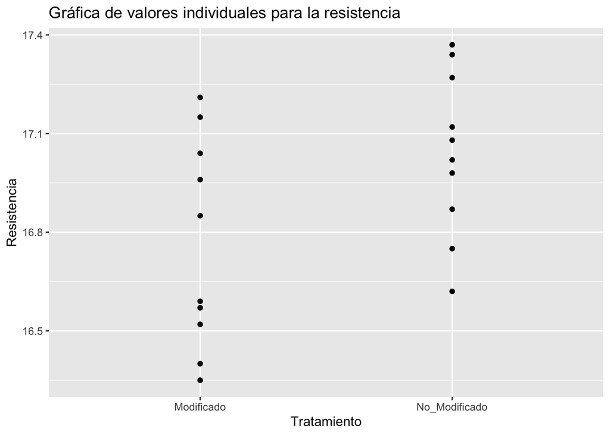

```r
p1 <- ggplot(df, aes(x = Tratamiento, y = Resistencia))  #
p1 + geom_point() + ggtitle("Gráfica de valores individuales para la resistencia")
```

Adicionalmente, se puede utilizar un gráfico de cajas para comparar medidas de posición como Q1(25%), Q2(50%) o mediana y Q3(75%).

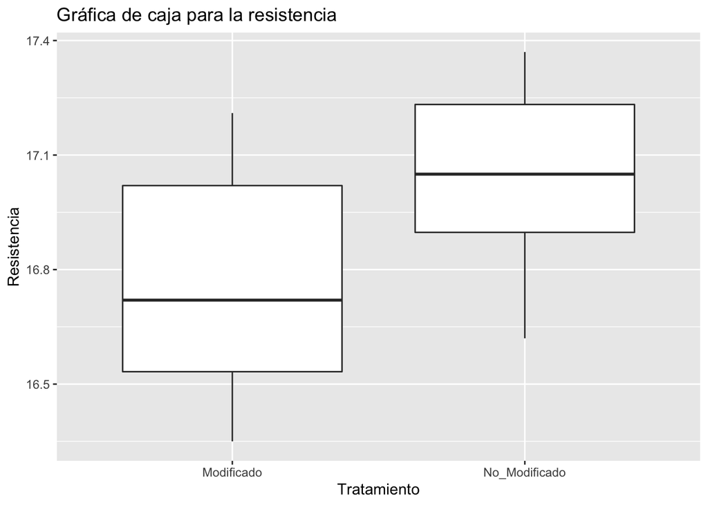

```r
p1 + geom_boxplot() + ggtitle("Gráfica de caja para la resistencia")
```

## Resumen estadístico

A continuación se presenta un resumen estadístico para cada uno de los tratamientos

```r
summary(Modificado)
```

```
##    Min. 1st Qu.  Median    Mean 3rd Qu.    Max.
##   16.35   16.53   16.72   16.76   17.02   17.21
```

```r
summary(No_Modificado)
```

```
##    Min. 1st Qu.  Median    Mean 3rd Qu.    Max.
##   16.62   16.90   17.05   17.04   17.23   17.37
```

Ademas se pueden calcular desviación y varianza, para el mortero modificado y no modificado respectivamente:

```r
sd(Modificado) # Desviación estandar
```

```
## [1] 0.3164455
```

```r
var(Modificado) # Varianza
```

```
## [1] 0.1001378
```

```r
sd(No_Modificado) # Desviación estandar
```

```
## [1] 0.2479158
```

```r
var(No_Modificado) # Varianza
```

```
## [1] 0.06146222
```

## Prueba t para varianzas iguales

A continuación se presenta la función utilizada para realizar la prueba t.

```r
t.test(x = Modificado, # Muestra 1
       y = No_Modificado, # Muestra 2
       mu = 0, # Delta para la diferencia de medias
       alternative = "two.sided", # Hipótesis alterna
       var.equal = TRUE, # ¿Se asume varianzas iguales?
       conf.level = 0.95) # Nivel de confianza
```

```
##
##  Two Sample t-test
##
## data:  Modificado and No_Modificado
## t = -2.1869, df = 18, p-value = 0.0422
## alternative hypothesis: true difference in means is not equal to 0
## 95 percent confidence interval:
##  -0.54507339 -0.01092661
## sample estimates:
## mean of x mean of y
##    16.764    17.042
```

## Prueba F para varianzas

A continuación se presenta la función y los resultados de una prueba F

```r
var.test(x = Modificado, # Muestra 1
         y = No_Modificado, # Muestra 2
         ratio = 1, # Relación entre varianzas
         alternative = "two.sided", # Hipòtesis alterna
         conf.level = 0.95) # Nivel de confianza
```

```
##
##  F test to compare two variances
##
## data:  Modificado and No_Modificado
## F = 1.6293, num df = 9, denom df = 9, p-value = 0.4785
## alternative hypothesis: true ratio of variances is not equal to 1
## 95 percent confidence interval:
##  0.4046845 6.5593806
## sample estimates:
## ratio of variances
##           1.629257
```

## Verificación de normalidad

A continuación se presentan las gráficas de normalidad para las dos muestras:

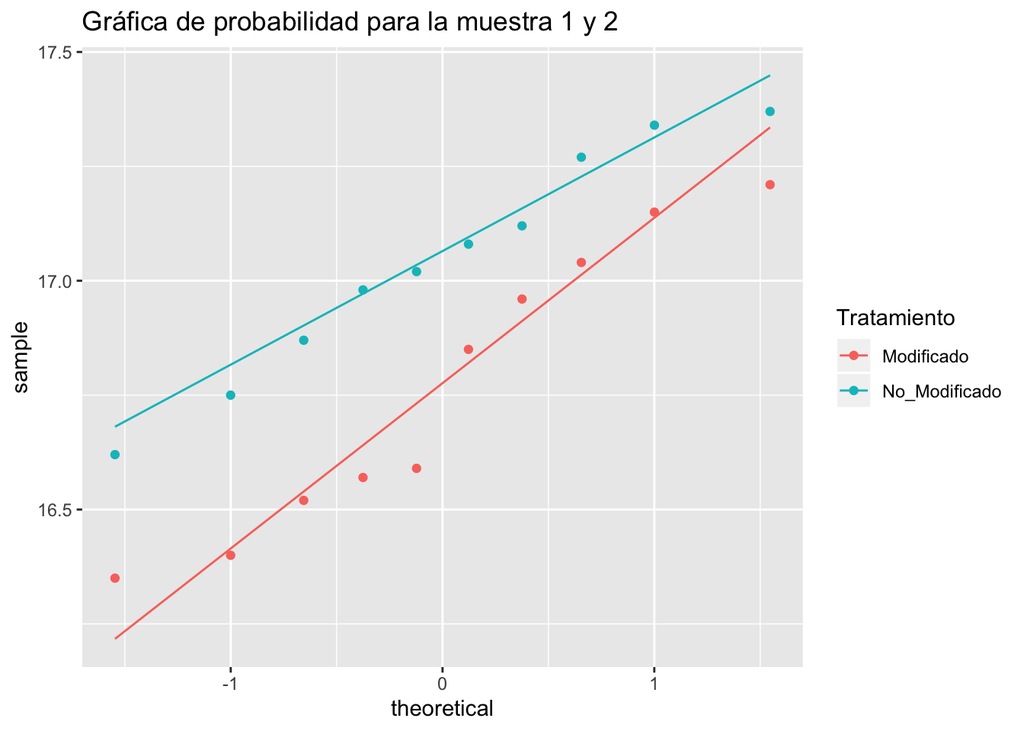

```r
p <- ggplot(df, aes(sample = Resistencia, color = Tratamiento))
p + stat_qq() + stat_qq_line() + ggtitle("Gráfica de probabilidad para la muestra 1 y 2")
```

# Experimentos para muestras pareadas

## Ejemplo 2.2 Tratamiento para reducción de peso

Diez personas adultas entre las edades de 35 y 50 participaron en un estudio para evaluar el efecto de la dieta y el ejercicio sobre el peso en Kg. El peso se midió en cada individuo inicialmente, y después de 4 meses de participar en un programa de ejercicio aeróbico y dieta baja en grasa, En la siguiente tabla se presentan los datos de las mediciones:

```r
# Organizar los datos en vectores
Antes <- c(95.0,84.1,90.1,85.6,88.0,87.7,95.8,83.9,83.0,94.6)
Despues <- c(90.4,80.3,84.1,75.5,86.6,75.0,89.9,86.2,84.0,82.6)
# Luego un data.frame
df2 <- data.frame(Antes,Despues)
df2 <- gather(data = df2, key = "Tratamiento", value = "Peso", Antes, Despues)
df2$Individuo <- rep(c(1:10), each = 1, times = 2)
```

## Análisis gráfico de las diferencias los pesos por individuo

A continuación se presenta un gráfico que compara las diferencias de peso antes y despues del tratamiento.

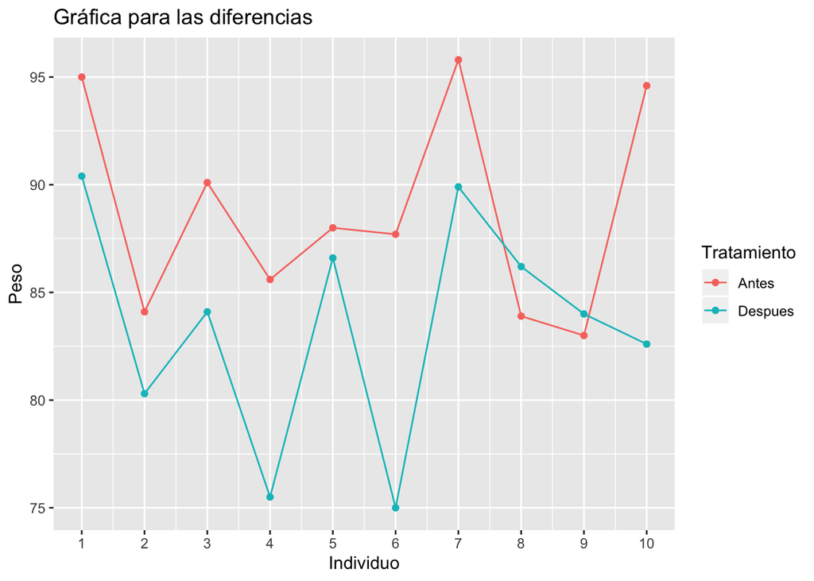

```r
ggplot2::ggplot(df2, aes(x = Individuo, y = Peso, color = Tratamiento)) +
  geom_line() + geom_point() + scale_x_continuous(breaks = c(1:10)) +
        ggtitle("Gráfica para las diferencias")
```

## Estadísticos para las diferencias

Se calculan las diferencias y se hace una estimaciónde la media, la varianza y la desviación estandar:

```r
mean(Antes-Despues)
```

```
## [1] 5.32
```

```r
var(Antes-Despues)
```

```
## [1] 26.54844
```

```r
sd(Antes-Despues)
```

```
## [1] 5.152518
```

## Prueba t pareada

A continuación se presenta la prueba t pareada en R.

```r
t.test(x = Antes,
       y = Despues,
       alternative = "two.sided",
       paired = T,
       conf.level = 0.95)
```

```
##
##  Paired t-test
##
## data:  Antes and Despues
## t = 3.2651, df = 9, p-value = 0.009759
## alternative hypothesis: true difference in means is not equal to 0
## 95 percent confidence interval:
##  1.63411 9.00589
## sample estimates:
## mean of the differences
##                    5.32
```

## Análisis de normalidad para las diferencias

Un análisis de la normalidad para las diferencias se presenta a continuación:

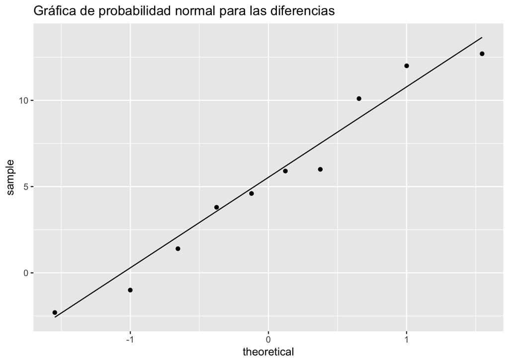

```r
ggplot2::ggplot(data.frame(Diferencia = Antes-Despues), aes(sample = Diferencia))+
  stat_qq() +
  stat_qq_line() +
  ggtitle("Gráfica de probabilidad normal para las diferencias")
```